# Practical Machine Learning_Course Project

Ellaqyzeng

28/09/2020

# Prediction of execution of an exercise based on measurements of accelerometers

## Background

Using devices such as Jawbone Up, Nike FuelBand, and Fitbit it is now possible to collect a large amount of data about personal activity relatively inexpensively. These type of devices are part of the quantified self movement – a group of enthusiasts who take measurements about themselves regularly to improve their health, to find patterns in their behavior, or because they are tech geeks. One thing that people regularly do is quantify how much of a particular activity they do, but they rarely quantify how well they do it. In this project, your goal will be to use data from accelerometers on the belt, forearm, arm, and dumbell of 6 participants. They were asked to perform barbell lifts correctly and incorrectly in 5 different ways.

In this project we will be building a prediction model to know how a certain user is lifting weights based on data obtained from an accelerometer. The purpose of the project was to build a prediction model to know how a certain user is lifting weights, based on data obtained from an accelerometer on the belt, forearm, arm, and dumbell of 6 participants.

## Preprocessing

The data was first read in using the `read.csv()` function:

```r
training <- read.csv("pml-training.csv")
```

The resulting data frame had 160 variables and 19,622 observations. The variables were rendered as one of three classes: numeric, integer, and factor. In addition, multiple columns had a number of entries where the contents were "" or NA. For consistency, all data columns were converted to numeric; at the same time, the first seven variables (index, user, timestamp, and window data) were discarded.

```r
## Create a vector with all of the columns' classes
columnClasses <- sapply(training,class)
## Convert all data columns to numeric
for(i in 8:159){
        if(columnClasses[i] != "numeric"){
            if(columnClasses[i] == "factor"){
                training[training[,i] == "",i] <- NA
                training[,i] <- as.numeric(as.character(training[,i]))
            }
            training[,i] <- as.numeric(training[,i])
        }
    }
## Remove the non-data columns
training <- training[,-c(1:7)]
```

This, in turn, generated a number of columns with NAs. In fact, any columns with NAs consisted almost entirely of NA entries;

```r
NAcount <- sapply(training, function(x) sum(is.na(x)))
unique(NAcount)
```

```
##  [1]     0 19226 19248 19622 19225 19216 19294 19296 19227 19293 19221 19218
## [13] 19220 19217 19300 19301 19299
```

The very small amount of data made any attempt to impute or otherwise fill in the data risky at best; as such, all columns with NA values were eliminated.

```r
training <- training[,ifelse(NAcount == 0, TRUE, FALSE)]
```

## Feature Selection

In order to select the relevant features, the various variables were plotted graphically. To begin, the variables were plotted a few at a time using boxplots in R's `featurePlot()` function, like so:

```r
featurePlot(x = training[,8:10], y = training$classe, plot = "box")
```

[output not shown]

At this point, the plots were visually inspected. Any variable where the boxes for a single variable had some significant differences were then further inspected via a stacked histogram, such as this one for the accel_belt_z variable above:

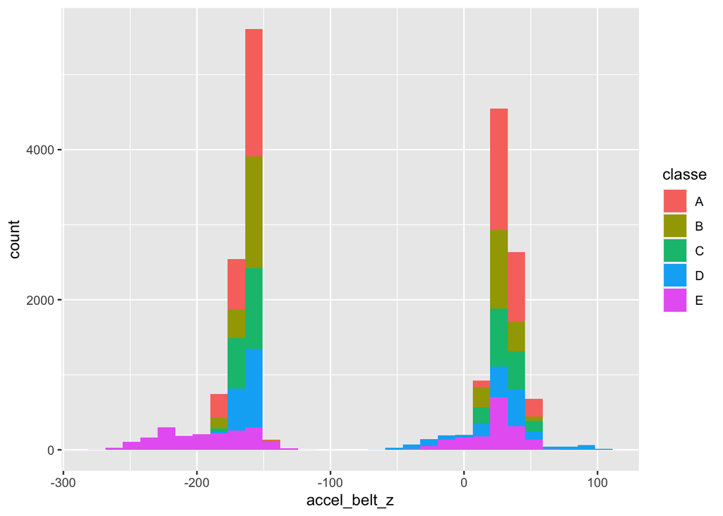

```r
ggplot(data = training, aes(x = accel_belt_z, fill = classe)) + geom_histogram()
```

Those that were determined to be potentially useful were then noted, and ultimately used in the final model.

## Cross validation

In order to properly cross-validate the model, the following procedure was repeated 10 times:

First, the training data was randomly split into two subsets - one for training, one for testing, like so:

```r
splitter <- createDataPartition(training$classe, p = 0.6, list = FALSE)
training_train <- training[splitter,]
training_test <- training[-splitter,]
```

The training_train subset was then used to determine a model, using the features selected previously. The models were then used to predict the outcomes of each training_test subset. Finally, the accuracy of each prediction was determined and recorded down.

Once all 10 iterations were complete, the accuracies were averaged together to get a single estimate of the accuracy, from which an estimate of the out-of-sample error could be determined.

## The Final Model

The final version of the model uses a total of seven variables: yaw_belt, accel_belt_z, gyros_arm_x, accel_arm_x, roll_dumbbell, gyros_dumbbell_x, and magnet_arm_x. The method used was the `train()` function's default method, the random forest.

The estimated accuracy of the model on the training_test subsets was 94%, indicating an out-of sample error of 6%.